# Automated Tagging of Maintenance Issues:

## A Keyword Detection and Ranking Approach

### Thurston Sexton + Mike Brundage

Also: compared to a Machine Learning one

```python
df_vocab.head(10)
```

| token | NE | alias | note | dumb |
| --- | --- | --- | --- | --- |
| replace | S | replace | NaN | NaN |
| unit | I | unit | NaN | NaN |
| motor | I | motor | NaN | NaN |
| spindle | I | spindle | NaN | NaN |
| leak | P | leak | NaN | NaN |
| valve | I | valve | NaN | NaN |
| replaced | S | replace | NaN | NaN |
| fault | P | fault | NaN | NaN |
| bar | I | bar | NaN | NaN |
| inop | P | inoperable | NaN | NaN |

```python
# how many instances of each keyword class are there?
print 'named entities: '
print 'I\tItem\nP\tProblem\nS\tSolution\nR\tRedundant'
print 'U\tUnknown\nX\tStop Word'
df_vocab.groupby("NE").nunique()
```

```
named entities:
I	Item
P	Problem
S	Solution
R	Redundant
U	Unknown
X	Stop Word
```

| NE | NE | alias | note | dumb |
| --- | --- | --- | --- | --- |
| I | 1 | 500 | 25 | 1 |
| P | 1 | 114 | 16 | 0 |
| R | 1 | 148 | 0 | 0 |
| S | 1 | 82 | 14 | 0 |
| U | 1 | 100 | 9 | 0 |
| X | 1 | 184 | 5 | 0 |

```python
# start up our NLP engine, Spacy wrapped in Textacy
docs = textacy.fileio.read.read_csv(raw_csv_filepath, encoding='utf-8')

content_stream, metadata_stream = textacy.fileio.split_record_fields(docs, 1)  # Descriptions in Col 6
corpus = textacy.Corpus(u'en', texts=content_stream, metadatas=metadata_stream)
```

```
# THIS GENERATED THE TOP N MOST IMPORTANT TOKENS VIA A DOC_TERM_MATRIX
# the engineers used this code-snippet to make tag_vocab.csv

from unicodedata import normalize

topn = 3000
topn_tok = [id2term[i] for i in doc_term_matrix.sum(axis=0).argsort()[0,-topn:].tolist()[0][::-1]]
with open('new_top{}.txt'.format(topn), 'wb') as f:
    for i in topn_tok:
        try:
            f.write(i+'\n')
        except UnicodeEncodeError:
            print i, '-->', normalize('NFKD', i).encode('ascii','ignore')
            f.write(normalize('NFKD', i).encode('ascii','ignore') +'\n')
```

[figure not shown]

```python
def get_norm_tokens(doc_n, doc_term_mat, id2term):
    doc = doc_term_mat[doc_n].toarray()
    return [id2term[i] for i in doc.nonzero()[1]]

def doc_to_tags(tokens, thes):
#     tokens = get_norm_terms(doc)
    tags = {'I':[], 'P':[], 'S':[]}
    untagged = []
    vocab_list = thes.index.tolist()
    for tok in tokens:
        if tok in vocab_list:  # recognized token?
            typ = thes.loc[tok]['NE']

            if typ in tags.keys():  #  I, P, or S?
                tags[typ] = list(set(tags[typ] + [thes.loc[tok]['alias'].tolist()]))
            else:  # R or X?
                pass # skip'em
        elif np.any([i in vocab_list for i in tok.split(' ')]):
            # If any subset of `tok` is itself a recognized token, skip'em
            pass
        else: # not recognized :(
            untagged += [tok]
    return tags, list(set(untagged))


def tag_corpus(corpus, thes):
    RT, I, S, P, UK = ([], [], [], [], [])

    # make the tf-idf embedding to tokenize with lemma/ngrams
    doc_term_matrix, id2term = textacy.vsm.doc_term_matrix(
            (doc.to_terms_list(ngrams=(1,2,3),
                               normalize=u'lemma',
                               named_entities=False,
#                                filter_stops=True,  # Nope! Not needed :)
                               filter_punct=True,
                               as_strings=True)
                for doc in corpus),
            weighting='tfidf',
            normalize=False,
            smooth_idf=False,
            min_df=2, max_df=0.95)  # each token in >2 docs, <95% of docs
    # iterate over all issues
    for  doc_n, doc in enumerate(tqdm_notebook(corpus)):
        tokens = get_norm_tokens(doc_n, doc_term_matrix, id2term)
        tags, unknown = doc_to_tags(tokens, thes)
        UK += [', '.join(unknown)]
        RT += [doc.text]
        I += [', '.join(tags['I'])]
        S += [', '.join(tags['S'])]
        P += [', '.join(tags['P'])]
    # get back a tagged DF
    return pd.DataFrame(data={
        'RawText': RT,
        'Items': I,
        'Problem': P,
        'Solution': S,
        'UK_tok': UK  # unknown
    }, columns = ['RawText','Items','Problem','Solution','UK_tok'])

df_pred = tag_corpus(corpus, df_vocab)
df_pred.head(10)
```

|  | RawText | Items | Problem | Solution | UK_tok |
| --- | --- | --- | --- | --- | --- |
| 0 | Broken bar feeder chain. Repaired | bar, chain, feeder_chain, feeder, bar_feeder, ... | broken | repair |  |
| 1 | No power. Replaced pin in pendant and powered ... | machine, cable, pendant, pin | short, power | replace |  |
| 2 | Smartscope harness broken. Parts ordered / Tec... | person, part | broken | repair, order | harness, smartscope |
| 3 | Check / Charge Accumulators. Where OK |  |  | charge, check | accumulators |
| 4 | Hyd leak at saw atachment. Replaced seal in sa... | seal, saw, attachment, hydraulic, saw_attachment | leak | replace | ml |
| 5 | CS1008 setup change over / from ARC1004. Compl... | unit, thread, thread_unit |  | setup, wire, complete, change |  |
| 6 | Gears on saw attachment tight and grinding per... | shelf, person, attachment, unit, gear | tight | rebuild, see, remove, replace |  |
| 7 | Check and charge Accumulators. Checked and cha... | accumulator |  | charge, check |  |
| 8 | St# 14 milling spindle repairs. Reapired | spindle, milling, st |  | repair | reapired |
| 9 | Hydraulic leak. Replaced ruptured hydraulic li... | hydraulic_line, line, hydraulic | leak, rupture | replace |  |

- A lot of items are taken care of automatically.
- where "problems" aren't listed, issue is generally routine maintenance.
- **Assumption**: Problem and Solution tags are almost entirely independent sets.
- We get a precise list of what *isn't* known for free...the "Unknowns".

#### How many have no remaining Unknown Tokens?

i.e. the mapping from token-space (domain) --> tag-space (codomain) is a surjection in the space of this issue

```python
df_pred[df_pred.UK_tok ==''].shape[0]
```

```
1807
```

#### How many got NO datafication?

i.e. for how many issues was this process completely worthless?

```python
# df_pred[df_pred.UK_tok ==''].dropna().shape
print df_pred[(df_pred[['Items','Problem','Solution']]=='').all(axis=1)].shape[0]
df_pred[(df_pred[['Items','Problem','Solution']]=='').all(axis=1)]
```

```
6
```

|  | RawText | Items | Problem | Solution | UK_tok |
| --- | --- | --- | --- | --- | --- |
| 631 | Unload automation not returning. |  |  |  | unload, automation |
| 1816 | . |  |  |  |  |
| 2467 | . |  |  |  |  |
| 2571 | Camshaft standstill. Gary!! |  |  |  | camshaft |
| 3191 | Disti water empty. Water filled; |  |  |  | disti, fill |
| 3405 | ??. |  |  |  |  |

### How well did we do at automating the job of Tagging Issues?

In order to somehow measure our success, we need something to compare with.

Thankfully, some hard-working engineers have gone through and manually tagged over 1200 maintenance issues **by hand**.

We can use these tags as the "gold standard" tags, with which to compare our automated keyword-->tag mapping.

#### But how will we measure this?

One way is straight-forward and easy to compute...the accuracy. The **accuracy score** measures, on average, how many predicted outputs match the true outputs perfectly:

\begin{equation} S_A = \frac{1}{n}\sum_{i=1}^{n} \mathbb{1}(T_i = P_i) \end{equation}

#### A better alternative :

This is an *overly-harsh metric* for the performance of multilabel classification, since it ignores *how close* we got to the correct output in each case. The **hamming score** is a more forgiving and/or useful metric: $$S_H = \frac{1}{n}\sum_{i=1}^{n} \frac{|T_i \cap P_i|}{|T_i \cup P_i|}$$ Note that the closely related **hamming loss** is similar to a distance metric, which unlike the others here is *better when low*.

#### Interpretability, please:

Finally, we can use the slightly more intuitive **precision**, **recall**, and their harmonic mean **$F_1$-score**. As put by Scikit-Learn:

> Intuitively, *precision* is the ability of the classifier *not to label as positive a sample that is negative*, and *recall* is the ability of the classifier *to find all the positive samples*.

Then, we can get some sort of combination that balances the two, embodied by $F_1$. Or, put formally:

$$Pr = \frac{1}{n}\sum_{i=1}^{n} \frac{|T_i \cap P_i|}{|P_i|}$$$$Re = \frac{1}{n}\sum_{i=1}^{n} \frac{|T_i \cap P_i|}{|T_i|}$$$$F_1 = \frac{1}{n}\sum_{i=1}^{n} \frac{2Pr_i Re_i}{Pr_i+Re_i}$$

If we want to model some difference between our importance of recall vs. precision, the generalized $F$-score is defined as:

$$F_{\beta} = \frac{1}{n}\sum_{i=1}^{n} (1+\beta^2)\frac{Pr_i Re_i}{\beta^2 Pr_i+Re_i}$$

From Van Rijsbergen, this is defined so that $F_{\beta}$:

> "measures the effectiveness of retrieval with respect to a user who attaches $\beta$ times as much importance to recall as precision".

In our case, Since we do not really trust that the original tags given by humans were all-inclusive (i.e. they might have left out tags below some un-known relevance threshold determined by their attention [read: boredom] level), we want to place more importance on recall in our $F$-measure. We'll use the commonly-applied $F_2$

```python
from sklearn.metrics import hamming_loss, accuracy_score, precision_recall_fscore_support
from scipy.stats import hmean  # harmonic mean

def hamming_score(y_true, y_pred, normalize=True, sample_weight=None):
    '''
    Compute the Hamming score (a.k.a. label-based accuracy) for the multi-label case
    http://stackoverflow.com/q/32239577/395857
    '''
    acc_list = []
    for i in range(y_true.shape[0]):
        set_true = set( np.where(y_true[i])[0] )
        set_pred = set( np.where(y_pred[i])[0] )
        #print('\nset_true: {0}'.format(set_true))
        #print('set_pred: {0}'.format(set_pred))
        tmp_a = None
        if len(set_true) == 0 and len(set_pred) == 0:
            tmp_a = 1
        else:
            tmp_a = len(set_true.intersection(set_pred))/\
                    float( len(set_true.union(set_pred)) )
        #print('tmp_a: {0}'.format(tmp_a))
        acc_list.append(tmp_a)
    return np.mean(acc_list)

def f_score(y_true, y_pred, beta=1.):
    '''
    Compute the Precision, Recall, and F-beta Score for the multi-label case
    http://stackoverflow.com/q/32239577/395857
    '''
    fsc_list = []
    pre_list = []
    rec_list = []
    for i in range(y_true.shape[0]):
        set_true = set( np.where(y_true[i])[0] )
        set_pred = set( np.where(y_pred[i])[0] )
        #print('\nset_true: {0}'.format(set_true))
        #print('set_pred: {0}'.format(set_pred))
        tmp_a = None
        if len(set_true) == 0 and len(set_pred) == 0:
            tmp_p, tmp_r, tmp_f = 1, 1, 1
        elif len(set_true.intersection(set_pred)) ==0:
            tmp_p = 0
            tmp_r = 0
            tmp_f = 0
        else:
            tmp_p = len(set_true.intersection(set_pred))/\
                    float( len(set_pred) )
            tmp_r = len(set_true.intersection(set_pred))/\
                    float( len(set_true) )
            try:
                tmp_f = ((1.+beta**2)*tmp_p*tmp_r)/((beta**2)*tmp_p + tmp_r)
            except ValueError:
                print tmp_p, tmp_r
                raise
        #print('tmp_a: {0}'.format(tmp_a))
        pre_list.append(tmp_p)
        rec_list.append(tmp_r)
        fsc_list.append(tmp_f)
    return np.array(pre_list), np.array(rec_list), np.array(fsc_list)

print '---Automatic Keyword Tagging (TF-IDF+human) ---'
print 'Accuracy Score: \t {:.2%}\nHamming Score: \t {:.2%}\nHamming Loss: \t {:.2e}'.format(accuracy_score(Y_true, Y_train),
                                                                          hamming_score(Y_true, Y_train),
                                                                          hamming_loss(Y_true, Y_train))

beta=2

print '\nPrecision: \t {:.2%}\nRecall: \t {:.2%}\nF{beta} Score: \t {:.2%}'.format(
    *[np.mean(i) for i in f_score(Y_true, Y_train, beta=beta)], beta=beta
)
# print '\nPrecision: \t {:.2%}\nRecall: \t {:.2%}\nF1 Score: \t {:.2%}'.format(
#     *[np.mean(i) for i in precision_recall_fscore_support(Y_true, Y_train)[:-1]]
# )
```

```
---Automatic Keyword Tagging (TF-IDF+human) ---
Accuracy Score: 	 1.82%
Hamming Score: 	 39.15%
Hamming Loss: 	 3.44e-03

Precision: 	 46.47%
Recall: 	 68.72%
F2 Score: 	 59.48%
```

## Using Machine Learning (SVM + Word2Vec)

### Benchmarking the auto-tagger

### Is there another way?

Now, it's important to note that all of the above was done **only** with a list of categorized keywords (i.e. some mapping from token-space to tag-space), and creating that mapping did not at all depend upon some human having tagged *individual issues* already...we were just using those tagged issues as a scoring/benchmark tool.

If we approach this as a classification problem, assuming these tagged issues *do exist*, we might attempt to train a classifier to predict the set of tags appropriate for given **raw-english** input.

#### Let's try this:

- first a mapping from token-space to some useful vector-space (could be tf-idf, maybe a topic model, but here we will use the shiny new **Word2Vec** semantic embedding vectors of our corpus, courtesy of Google+Textacy/Spacy).
- Then we will train a **classifier** to exactly match the **Multilabel** output, represented by the individual human-tagged issues.

Support-vector-machines work amazingly well on text embedding classification jobs, so let's use a linear SVC trained using stochasic gradient descent (SGD) via sklearn. We should also minimize overfitting with this hugely dimensional job, so we'll regularize with an elasticnet penalty (L1+L2).

[figure not shown]

```
from sklearn.multiclass import OneVsRestClassifier
from sklearn.linear_model import SGDClassifier

X_train = corpus.vectors[mask]
clf = OneVsRestClassifier(SGDClassifier(#class_weight='balanced',  # compensate for class freqs
                                        penalty='elasticnet'   # L1 + L2 regularized
                                        ), n_jobs=3  # 3-cores for the one-vs-all
                         )
clf.fit(X_train, Y_true)
Y_train_w2v = clf.predict(X_train)
```

```python
print '---W2V Embeddings with SVC (OneVsRest, SGD)---'
print 'Accuracy Score: \t {:.2%}\nHamming Score: \t {:.2%}\nHamming Loss: \t {:.2e}'.format(accuracy_score(Y_true, Y_train_w2v),
                                                                          hamming_score(Y_true, Y_train_w2v),
                                                                          hamming_loss(Y_true, Y_train_w2v))
beta=2
print '\nPrecision: \t {:.2%}\nRecall: \t {:.2%}\nF{beta} Score: \t {:.2%}'.format(
    *[np.mean(i) for i in f_score(Y_true, Y_train_w2v, beta=beta)], beta=beta
)
# print '\nPrecision: \t {:.2%}\nRecall: \t {:.2%}\nF1 Score: \t {:.2%}'.format(
#     *[np.mean(i) for i in precision_recall_fscore_support(Y_true, Y_train_w2v)[:-1]]
# )
```

```
---W2V Embeddings with SVC (OneVsRest, SGD)---
Accuracy Score: 	 14.50%
Hamming Score: 	 54.51%
Hamming Loss: 	 2.02e-03

Precision: 	 70.78%
Recall: 	 71.19%
F2 Score: 	 67.80%
```

```python
interact(compare_by_issue, iss=widgets.BoundedIntText(
                    value=0,
                    min=0,
                    max=3437,
                    description='Pick an Issue No.:',
                    step=1
                    )
               );
# display(w)
```

# Analysis

Now that we have tags, what do we do with them?

- **MaxLikelihood Example Demo**
- **Something simpler?**

First let's get some of the most common tags and convert them into binary indicators on a per-issue basis.

```python
# item_counts = Item_vecs.sum(axis=0)
# relevant = [(binner.classes_[i], item_counts[i], Item_vecs[:,i]) for i in item_counts.argsort()[-20:][::-1]]
event_df = pd.DataFrame(columns = [i[0] for i in relevant if i[0]!=u''],
             data = np.array([i[2] for i in relevant if i[0]!=u'']).T)
# plt.barh()
event_df.head(10)
```

|  | unit | spindle | hydraulic | motor | valve | bar | machine | accumulator | coolant | person | ... | reset | charge | clear | swap | load | cycle | level | check_request | report | train_operator |
| --- | --- | --- | --- | --- | --- | --- | --- | --- | --- | --- | --- | --- | --- | --- | --- | --- | --- | --- | --- | --- | --- |
| 0 | 0 | 0 | 0 | 0 | 0 | 1 | 0 | 0 | 0 | 0 | ... | 0 | 0 | 0 | 0 | 0 | 0 | 0 | 0 | 0 | 0 |
| 1 | 0 | 0 | 0 | 0 | 0 | 0 | 1 | 0 | 0 | 0 | ... | 0 | 0 | 0 | 0 | 0 | 0 | 0 | 0 | 0 | 0 |
| 2 | 0 | 0 | 0 | 0 | 0 | 0 | 0 | 0 | 0 | 1 | ... | 0 | 0 | 0 | 0 | 0 | 0 | 0 | 0 | 0 | 0 |
| 3 | 0 | 0 | 0 | 0 | 0 | 0 | 0 | 0 | 0 | 0 | ... | 0 | 1 | 0 | 0 | 0 | 0 | 0 | 0 | 0 | 0 |
| 4 | 0 | 0 | 1 | 0 | 0 | 0 | 0 | 0 | 0 | 0 | ... | 0 | 0 | 0 | 0 | 0 | 0 | 0 | 0 | 0 | 0 |
| 5 | 1 | 0 | 0 | 0 | 0 | 0 | 0 | 0 | 0 | 0 | ... | 0 | 0 | 0 | 0 | 0 | 0 | 0 | 0 | 0 | 0 |
| 6 | 1 | 0 | 0 | 0 | 0 | 0 | 0 | 0 | 0 | 1 | ... | 0 | 0 | 0 | 0 | 0 | 0 | 0 | 0 | 0 | 0 |
| 7 | 0 | 0 | 0 | 0 | 0 | 0 | 0 | 1 | 0 | 0 | ... | 0 | 1 | 0 | 0 | 0 | 0 | 0 | 0 | 0 | 0 |
| 8 | 0 | 1 | 0 | 0 | 0 | 0 | 0 | 0 | 0 | 0 | ... | 0 | 0 | 0 | 0 | 0 | 0 | 0 | 0 | 0 | 0 |
| 9 | 0 | 0 | 1 | 0 | 0 | 0 | 0 | 0 | 0 | 0 | ... | 0 | 0 | 0 | 0 | 0 | 0 | 0 | 0 | 0 | 0 |

10 rows × 58 columns

Now we want to get other information, say, the *time* a problem was submitted.

```python
# og_data_loc = os.path.join(data_directory, 'Maintenance_All_Clean.xlsx')
og_data = pd.read_excel(raw_excel_filepath,header=1, parse_dates=True, index_col='DATE RECEIVED')
                        #[['DATE RECEIVED','Time Submitted']])
# og_data.set_index('DATE RECEIVED_Time Submitted', inplace=True)
# og_data.set_index('DATE RECEIVED', inplace=True)

# print og_data.iloc[1381]
og_data.head()
```

| DATE RECEIVED | Description | Resolution | Item Tags | Action Tags | Action Tags.1 | Item Tags.1 | Unnamed: 6 | MACH | DOWN Y/N | Time Submitted | DATE COMPLETED | Time Up | REQUESTED BY | TECH | Tech Full Name | Part in Process | Unnamed: 17 | Unnamed: 18 | Unnamed: 19 | Unnamed: 20 |
| --- | --- | --- | --- | --- | --- | --- | --- | --- | --- | --- | --- | --- | --- | --- | --- | --- | --- | --- | --- | --- |
| 2015-01-11 | Broken bar feeder chain | Repaired | bar_feeder, chain, bar | broken | repair | bar_feeder, chain, bar | NaN | H27 | Y | NaN | 2015-01-11 00:00:00 | NaN | Alex | AP | Anthony Paolillo | NaN | NaN | NaN | NaN | NaN |
| 2015-01-14 | No power | Replaced pin in pendant and powered machine -P... | pendant_cable, cable | short, no_power | replace | pin | NaN | H5 | Y | NaN | 2015-11-16 00:00:00 | NaN | Bruce | JPM / AP | John Murray/ Anthony Paolillo | NaN | DK | Denis Kusiak | NaN | Mike: 7.5 hours |
| 2015-02-27 | Smartscope harness broken | Parts ordered / Tech repaired | smartscope_harness | broken | order, repair | smartscope_harness | NaN | QA | Y | NaN | 2015-02-27 00:00:00 | NaN | QA | DK / Tech | Denis Kusiak/ Technician | NaN | NaN | NaN | NaN | Thurston: 4 hours |
| 2015-02-27 | Check / Charge Accumulators | Where OK | accumulator | check, charge | no_problem_detected | NaN | NaN | H18 | N | NaN | 2015-02-27 00:00:00 | NaN | Steve C | SA | Steve Andreozzi | NaN | NaN | NaN | NaN | NaN |
| 2015-02-27 | Hyd leak at saw atachment | Replaced seal in saw attachment but still leak... | hydraulic, saw_attachment, saw | leak | replace, need_guy | seal | NaN | H23 | N | NaN | 2015-02-27 00:00:00 | NaN | Steve C | JPM | John Murray | NaN | NaN | NaN | NaN | NaN |

and then, re-index our indicator items.

```python
df_raw.head()
event_df.index = og_data.index
event_df.index = pd.to_datetime(event_df.index, errors='coerce')
event_df.iloc[2500:2505]
```

| DATE RECEIVED | unit | spindle | hydraulic | motor | valve | bar | machine | accumulator | coolant | person | ... | reset | charge | clear | swap | load | cycle | level | check_request | report | train_operator |
| --- | --- | --- | --- | --- | --- | --- | --- | --- | --- | --- | --- | --- | --- | --- | --- | --- | --- | --- | --- | --- | --- |
| 2016-08-01 | 0 | 0 | 1 | 0 | 0 | 0 | 0 | 0 | 0 | 0 | ... | 0 | 0 | 0 | 0 | 0 | 0 | 0 | 0 | 0 | 0 |
| 2016-08-01 | 0 | 1 | 0 | 0 | 0 | 0 | 0 | 0 | 0 | 0 | ... | 0 | 0 | 0 | 0 | 0 | 0 | 0 | 0 | 0 | 0 |
| 2016-08-01 | 0 | 0 | 0 | 0 | 0 | 0 | 0 | 0 | 0 | 0 | ... | 0 | 0 | 0 | 0 | 0 | 0 | 0 | 0 | 0 | 0 |
| 2016-08-01 | 0 | 0 | 0 | 0 | 0 | 0 | 0 | 0 | 0 | 0 | ... | 0 | 0 | 0 | 0 | 0 | 0 | 0 | 0 | 0 | 0 |
| 2016-08-01 | 0 | 0 | 0 | 0 | 0 | 0 | 0 | 0 | 1 | 0 | ... | 1 | 0 | 1 | 0 | 0 | 0 | 0 | 0 | 0 | 0 |

5 rows × 58 columns

Let's pick a few interesting items, and see how often they come up as a problem/solution:

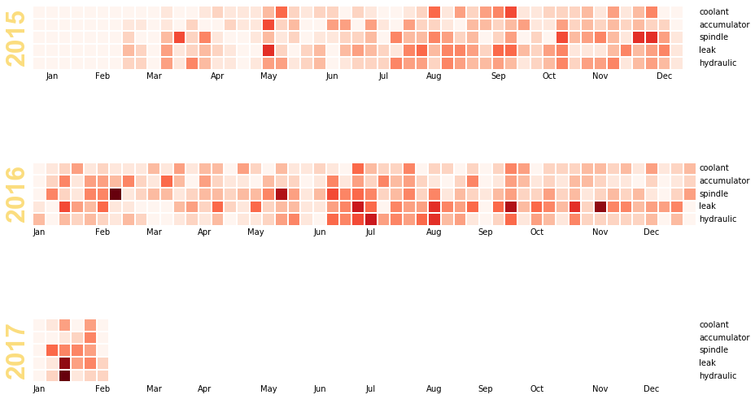

```python
# plt.figure
calendarplot(event_df[['hydraulic',
                       'leak',
                       'spindle',
                       'accumulator',
                       'coolant'
                       ]],
             how='sum', fig_kws={'figsize':(13,9)});
# yearplot(event_df[['hydraulic', 'spindle','accumulator', 'operator']], how='sum', fig_kws={'figsize':(12,8)})
# og_data[event_df.index.isnull()]
```

```python
event_df[event_df.operator==1].sum().to_frame(name='operator_incidents').sort_values('operator_incidents',
                                                                                     ascending=False).iloc[:10]
```

|  | operator_incidents |
| --- | --- |
| operator | 162 |
| level | 67 |
| train_operator | 64 |
| replace | 32 |
| fault | 29 |
| loose | 26 |
| bar | 20 |
| broken | 20 |
| machine | 19 |
| remove | 17 |

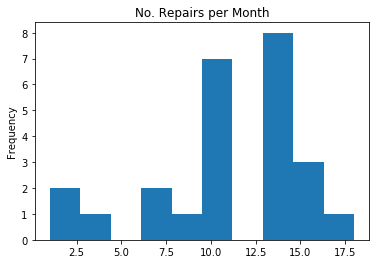

```python
week_df = event_df.resample('M').agg(sum).fillna(0)
week_df['repair'].plot(kind='hist')
plt.title('No. Repairs per Month')
```

## Beginning of RUL analysis

We need to approximate the idea of "machine failure" as opposed to "machine maintenance" (compare to "patient care" vs. "patient death".

One way is to only find items occuring with "broken" **AND** "replace". While not 100% accurate, it's definitely a quick and dirty way to estimate the failure rate.

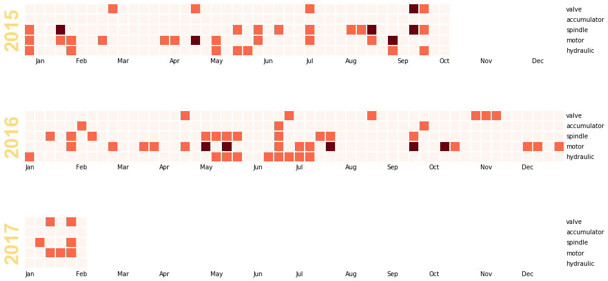

```python
weekly_replace = event_df[(event_df['broken']==1) & (event_df['replace']==1)].resample('W').agg(sum).fillna(0)
calendarplot(weekly_replace[['hydraulic',
                             'motor',
                             'spindle',
                             'accumulator',
                             'valve'
                            ]],
             fig_kws={'figsize':(14,8)});
```

# Taxonomy Generation

```python
itm_relevant = get_relevant(df_pred, 'Items', topn=500)
itm_event = pd.DataFrame(columns = [i[0] for i in itm_relevant if i[0]!=u''],
             data = np.array([i[2] for i in itm_relevant if i[0]!=u'']).T)
```

```python
coocc = itm_event.T.dot(itm_event)
occ = np.diagonal(np.copy(coocc))

np.fill_diagonal(coocc.values, 0)
coocc.head()
```

|  | unit | spindle | hydraulic | motor | valve | bar | machine | accumulator | coolant | person | ... | clamp_jaw_set | bar_load_sequence | hinge | valve_stem | pneumatic | hinge_belt | valve_plate | intake_filter | direct_current | loader_tray |
| --- | --- | --- | --- | --- | --- | --- | --- | --- | --- | --- | --- | --- | --- | --- | --- | --- | --- | --- | --- | --- | --- |
| unit | 0 | 30 | 29 | 60 | 16 | 5 | 10 | 8 | 6 | 25 | ... | 0 | 0 | 0 | 0 | 0 | 0 | 0 | 0 | 0 | 0 |
| spindle | 30 | 0 | 22 | 20 | 24 | 8 | 14 | 2 | 3 | 22 | ... | 0 | 0 | 0 | 0 | 0 | 0 | 0 | 0 | 0 | 0 |
| hydraulic | 29 | 22 | 0 | 23 | 51 | 8 | 12 | 15 | 6 | 15 | ... | 3 | 1 | 0 | 1 | 0 | 0 | 2 | 2 | 2 | 0 |
| motor | 60 | 20 | 23 | 0 | 2 | 1 | 8 | 1 | 22 | 14 | ... | 0 | 0 | 0 | 0 | 1 | 0 | 0 | 0 | 2 | 0 |
| valve | 16 | 24 | 51 | 2 | 0 | 12 | 11 | 9 | 8 | 12 | ... | 0 | 0 | 0 | 3 | 0 | 0 | 2 | 0 | 0 | 0 |

5 rows × 499 columns

```python
dist_mat = coocc/np.dot(np.sqrt(occ).T, np.sqrt(occ))

dist_mat.head()
```

|  | unit | spindle | hydraulic | motor | valve | bar | machine | accumulator | coolant | person | ... | clamp_jaw_set | bar_load_sequence | hinge | valve_stem | pneumatic | hinge_belt | valve_plate | intake_filter | direct_current | loader_tray |
| --- | --- | --- | --- | --- | --- | --- | --- | --- | --- | --- | --- | --- | --- | --- | --- | --- | --- | --- | --- | --- | --- |
| unit | 0.000000 | 0.002106 | 0.002035 | 0.004211 | 0.001123 | 0.000351 | 0.000702 | 0.000561 | 0.000421 | 0.001755 | ... | 0.000000 | 0.00000 | 0.0 | 0.000000 | 0.00000 | 0.0 | 0.00000 | 0.00000 | 0.00000 | 0.0 |
| spindle | 0.002106 | 0.000000 | 0.001544 | 0.001404 | 0.001684 | 0.000561 | 0.000983 | 0.000140 | 0.000211 | 0.001544 | ... | 0.000000 | 0.00000 | 0.0 | 0.000000 | 0.00000 | 0.0 | 0.00000 | 0.00000 | 0.00000 | 0.0 |
| hydraulic | 0.002035 | 0.001544 | 0.000000 | 0.001614 | 0.003579 | 0.000561 | 0.000842 | 0.001053 | 0.000421 | 0.001053 | ... | 0.000211 | 0.00007 | 0.0 | 0.000070 | 0.00000 | 0.0 | 0.00014 | 0.00014 | 0.00014 | 0.0 |
| motor | 0.004211 | 0.001404 | 0.001614 | 0.000000 | 0.000140 | 0.000070 | 0.000561 | 0.000070 | 0.001544 | 0.000983 | ... | 0.000000 | 0.00000 | 0.0 | 0.000000 | 0.00007 | 0.0 | 0.00000 | 0.00000 | 0.00014 | 0.0 |
| valve | 0.001123 | 0.001684 | 0.003579 | 0.000140 | 0.000000 | 0.000842 | 0.000772 | 0.000632 | 0.000561 | 0.000842 | ... | 0.000000 | 0.00000 | 0.0 | 0.000211 | 0.00000 | 0.0 | 0.00014 | 0.00000 | 0.00000 | 0.0 |

5 rows × 499 columns

```python
import networkx as nx

G = nx.from_numpy_matrix(dist_mat.values)
G = nx.relabel_nodes(G, dict(zip(G.nodes(), dist_mat.columns)))
```

```python
# cent = pd.Series(nx.closeness_centrality(G, distance='weight'))
# cent = pd.Series(nx.betweenness_centrality(G))
# cent = pd.Series(nx.eigenvector_centrality(G))
cent = pd.Series(nx.pagerank(G))
```

```python
cent.sort_values(ascending=False).iloc[:10].index.values
# cent
```

```
array([u'unit', u'hydraulic', u'bar', u'spindle', u'motor', u'valve',
       u'person', u'machine', u'coolant', u'screw'], dtype=object)
```

```python
def heymann_taxonomy(dist_mat, cent_prog='pr', tau=5e-4,
                     dynamic=False, dotfile=None, verbose=False):
    """
    dist_mat: dataframe containing similarity matrix, indexed and named by tags
    cent_prog: algorithm to use in calculating node centrality
        pr: PageRank
        eig: eigencentrality
        btw: betweenness
        cls: closeness
    tau: similarity threshold for retaining a node
    dynamic: re-calculate centrality after adding every tag
    write_dot: fname or None, where to save a .dot, if any.
    verbose: print some stuff
    """
#     tau = 5e-4
    cent_dict = {
        'pr': nx.pagerank,
        'eig': nx.eigenvector_centrality,
        'btw': nx.betweenness_centrality,
        'cls': nx.closeness_centrality
    }

    # Create the co-occurence graph, G
    G = nx.from_numpy_matrix(dist_mat.values)
    G = nx.relabel_nodes(G, dict(zip(G.nodes(), dist_mat.columns)))

    # Calculate the centrality of nodes in G
    cent = pd.Series(cent_dict[cent_prog](G)).sort_values(ascending=False)
    root = cent.index[0]

    # Init the taxonomy D (DAG)
    D = nx.DiGraph()
    D.add_node(root)

    for n in tqdm_notebook(range(dist_mat.shape[0])):

        # Pick the most central node in G, and the node in D most similar to it
        tag = cent.index[0]
        neighbor_sim =  {k: dist_mat.loc[tag,k] for k in D.nodes()}
        parent = max(neighbor_sim, key=lambda key: neighbor_sim[key])

        if neighbor_sim[parent] > tau:
            # above threshold--> direct child
            D.add_node(tag)
            D.add_edge(parent, tag)
        else:
    #         D.add_edge(root, descendant)  # do not enforce single taxonomy
            # New "top-level" tag
            D.add_node(tag)
            pass

        if dynamic:
            # recalculate node centralities after removing each <tag>
            # EXPENSIVE.
            G.remove_node(tag)
            cent = pd.Series(cent_dict[cent_prog](G)).sort_values(ascending=False)
        else:
            cent.drop(tag, inplace=True)

    if verbose:
        print root # most "general" topic
        print nx.isolates(D) # child-less nodes (i.e. central AND dissimilar)


    D.remove_nodes_from(nx.isolates(D))  # not useful for taxonomy

    if dotfile is not None:
        from networkx.drawing.nx_pydot import graphviz_layout, write_dot
        D.graph['graph']={'rankdir':'LR', 'splines':'true',
                          'ranksep':'3'}
        write_dot(D, dotfile)

    return D

D = heymann_taxonomy(dist_mat,
                     cent_prog='pr', # dynamic=True,
                     dotfile='tax.dot')
```

```python
# from networkx.drawing.nx_pydot import graphviz_layout, write_dot
# write_dot(D, 'tax.dot')
!dot -Tpng tax.dot >tax.png
```

```
The process cannot access the file because it is being used by another process.
```

[figure not shown]

```python
from numpy import seterr,isneginf,array
seterr(divide='ignore')
node_df = pd.concat([np.log(pd.Series(nx.clustering(G, weight='weight'), name='clustering')),
                     np.log(pd.Series(nx.pagerank(G), name='log_PR')),
                     np.log(pd.Series(nx.closeness_centrality(G), name='log_CentC')),
                     np.log(pd.Series(nx.betweenness_centrality(G),
                                      name='log_CentB')).replace([np.inf, -np.inf], np.nan)], axis=1)
node_df.head()
```

|  | clustering | log_PR | log_CentC | log_CentB |
| --- | --- | --- | --- | --- |
| 24v | -4.693024 | -6.913525 | -0.692143 | -8.379384 |
| accumulator | -4.891039 | -5.251952 | -0.585106 | -5.254192 |
| actual_issue | -5.003690 | -7.328116 | -0.691137 | -9.548959 |
| actuator | -4.985127 | -6.222952 | -0.625659 | -6.327020 |
| aim | -5.105625 | -7.227074 | -0.732522 | -9.384059 |

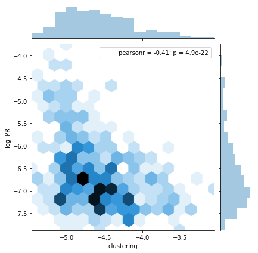

```python
sns.jointplot('clustering', 'log_PR', data=node_df, kind='hex')
```

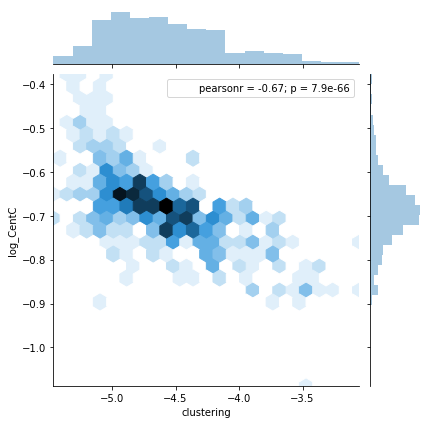

```python
sns.jointplot('clustering', 'log_CentC', data=node_df, kind='hex')
```

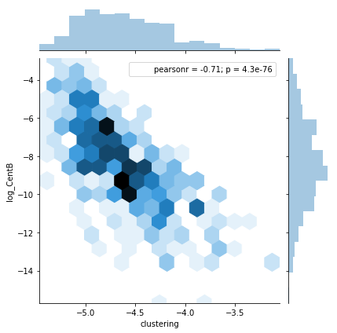

```python
sns.jointplot('clustering', 'log_CentB', data=node_df, kind='hex')
```

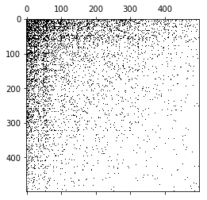

```python
plt.spy(coocc.values)
```

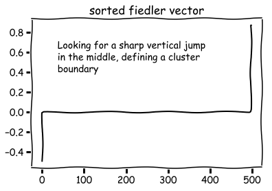

```python
with plt.xkcd():
    plt.title('sorted fiedler vector')
    fied = nx.fiedler_vector(G)
    plt.plot(np.arange(fied.shape[0]),np.sort(nx.fiedler_vector(G)), 'k')
    # place a text box in upper left in axes coords
    plt.text(0.1, 0.85, ' Looking for a sharp vertical jump\n in the middle, defining a cluster\n boundary',
             transform=plt.gca().transAxes, fontsize=14, verticalalignment='top'
            )
# arrangement = np.argsort(nx.fiedler_vector(G))
```

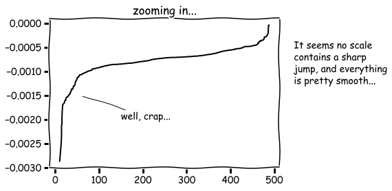

```python
with plt.xkcd():
    plt.title('zooming in...')
    fied = nx.fiedler_vector(G)
    plt.plot(np.arange(fied.shape[0])[10:-10],np.sort(fied)[10:-10], 'k')
    plt.annotate(
        'well, crap...',
        xy=(60,-.0015), arrowprops=dict(arrowstyle='-'), xytext=(150, -.002)
    )
    plt.text(1.05, 0.85, ' It seems no scale\n contains a sharp\n jump, and everything\n is pretty smooth...',
         transform=plt.gca().transAxes, fontsize=14, verticalalignment='top'
        )
#     plt.yscale('symlog', linthresy=(-.0010, -.0005))
```

```python
nx.spectral_ordering(G, weight=None)
```

```
[u'inverter_guard',
 u'table_down_sensor',
 u'unit_safety',
 u'safety_guard',
 u'brush_unit_safety',
 u'unit_safety_guard',
 u'dresser_control_valve',
 u'dresser_control',
 u'platform',
 u'loader_tray',
 u'pneumatic',
 u'i_2',
 u'door_interlock',
 u'vogel_unit',
 u'filtermist',
 u'valve_plate',
 u'valve_stem',
 u'recess_unit',
 u'chip_conveyor_belt',
 u'stripper',
 u'chip_stripper',
 u'high_pressure_coolant_hose',
 u'iemca_flag',
 u'hook',
 u'battery',
 u'wheel_control_valve',
 u'mist',
 u'draw_bar',
 u'bar_loader_chain',
 u'impellor',
 u'flag_proximity_cable',
 u'st_2_drill_detector',
 u'chip_guard',
 u'direct_current',
 u'skimmer',
 u'drawbar',
 u'high_pressure_accumulator',
 u'wide',
 u'offload_conveyor_belt',
 u'exit_conveyor',
```

[output cut: 444 more lines]

```
 u'hole',
 u'side_b',
 u'indexer',
 u'laser',
 u'starter',
 u'pendant',
 u'aim',
 u'room',
 u'center',
 u'stack',
 u'side_a',
 u'unit_2',
 u'light',
 u'bulb',
 u'workzone']
```

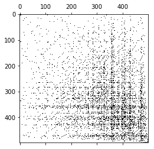

```python
plt.spy(coocc.loc[nx.spectral_ordering(G, weight=None),
                  nx.spectral_ordering(G, weight=None)])
```

[figure not shown]

```python
# from networkx.algorithms import community
# community.centrality.girvan_newman(G)
# from networkx.algorithms import community
# list(community.k_clique_communities(G, 4))

with plt.xkcd():
    list_tups = np.random.rand(5,2)
    f,ax = plt.subplots()
    for n,tup in enumerate(list_tups):
        prev=list_tups[n-1]
        d = np.linalg.norm(tup-prev)
        u = (tup-prev)/d
#         print d
        ax.annotate(s='node', xy=prev+(d-.05)*u, xytext=prev-(.05,.01), arrowprops={'arrowstyle':'->'})
#         print tuple(tup), tuple(list_tups[n-1])
```

```python
from networkx.readwrite import json_graph
from networkx.algorithms.traversal.depth_first_search import dfs_tree
import json

subD = dfs_tree(D, 'unit')

with open('d3tree.json', 'wb') as outfile:
    s=json.dump(json_graph.tree.tree_data(subD, 'unit'), outfile)
```

[output not shown]

[output cut: 212 more lines]

[output not shown]

```python
%%writefile f2.template
<!DOCTYPE html>
<meta charset="utf-8">
<style>

.node {
  cursor: pointer;
}

.node circle {
  fill: #fff;
  stroke: steelblue;
  stroke-width: 1.5px;
}

.node text {
  font: 10px sans-serif;
}

.link {
  fill: none;
  stroke: #ccc;
  stroke-width: 1.5px;
}

</style>
<body>
<script src="//d3js.org/d3.v3.min.js"></script>
<script>

var margin = {top: 20, right: 120, bottom: 20, left: 120},
    width = 1500 - margin.right - margin.left,
    height = 1200 - margin.top - margin.bottom;

var i = 0,
    duration = 750,
    root;

var tree = d3.layout.tree()
    .size([height, width]);

var diagonal = d3.svg.diagonal()
    .projection(function(d) { return [d.y, d.x]; });

var svg = d3.select("body").append("svg")
    .attr("width", width + margin.right + margin.left)
    .attr("height", height + margin.top + margin.bottom)
  .append("g")
    .attr("transform", "translate(" + margin.left + "," + margin.top + ")");

d3.json("d3tree.json", function(error, flare) {
  if (error) throw error;

  root = flare;
  root.x0 = height / 2;
  root.y0 = 0;

  function collapse(d) {
    if (d.children) {
      d._children = d.children;
      d._children.forEach(collapse);
      d.children = null;
    }
  }

  root.children.forEach(collapse);
  update(root);
});

d3.select(self.frameElement).style("height", "800px");

function update(source) {

  // Compute the new tree layout.
  var nodes = tree.nodes(root).reverse(),
      links = tree.links(nodes);

  // Normalize for fixed-depth.
  nodes.forEach(function(d) { d.y = d.depth * 180; });

  // Update the nodes…
  var node = svg.selectAll("g.node")
      .data(nodes, function(d) { return d.id || (d.id = ++i); });

  // Enter any new nodes at the parent's previous position.
  var nodeEnter = node.enter().append("g")
      .attr("class", "node")
      .attr("transform", function(d) { return "translate(" + source.y0 + "," + source.x0 + ")"; })
      .on("click", click);

  nodeEnter.append("circle")
      .attr("r", 1e-6)
      .style("fill", function(d) { return d._children ? "lightsteelblue" : "#fff"; });

  nodeEnter.append("text")
      .attr("x", function(d) { return d.children || d._children ? -10 : 10; })
      .attr("dy", ".35em")
      .attr("text-anchor", function(d) { return d.children || d._children ? "end" : "start"; })
      .text(function(d) { return d.id; })
      .style("fill-opacity", 1e-6);

  // Transition nodes to their new position.
  var nodeUpdate = node.transition()
      .duration(duration)
      .attr("transform", function(d) { return "translate(" + d.y + "," + d.x + ")"; });

  nodeUpdate.select("circle")
      .attr("r", 4.5)
      .style("fill", function(d) { return d._children ? "lightsteelblue" : "#fff"; });

  nodeUpdate.select("text")
      .style("fill-opacity", 1);

  // Transition exiting nodes to the parent's new position.
  var nodeExit = node.exit().transition()
      .duration(duration)
      .attr("transform", function(d) { return "translate(" + source.y + "," + source.x + ")"; })
      .remove();

  nodeExit.select("circle")
      .attr("r", 1e-6);

  nodeExit.select("text")
      .style("fill-opacity", 1e-6);

  // Update the links…
  var link = svg.selectAll("path.link")
      .data(links, function(d) { return d.target.id; });

  // Enter any new links at the parent's previous position.
  link.enter().insert("path", "g")
      .attr("class", "link")
      .attr("d", function(d) {
        var o = {x: source.x0, y: source.y0};
        return diagonal({source: o, target: o});
      });

  // Transition links to their new position.
  link.transition()
      .duration(duration)
      .attr("d", diagonal);

  // Transition exiting nodes to the parent's new position.
  link.exit().transition()
      .duration(duration)
      .attr("d", function(d) {
        var o = {x: source.x, y: source.y};
        return diagonal({source: o, target: o});
      })
      .remove();

  // Stash the old positions for transition.
  nodes.forEach(function(d) {
    d.x0 = d.x;
    d.y0 = d.y;
  });
}

// Toggle children on click.
function click(d) {
  if (d.children) {
    d._children = d.children;
    d.children = null;
  } else {
    d.children = d._children;
    d._children = null;
  }
  update(d);
}

</script>
```

```
Overwriting f2.template
```

```python
from IPython.display import IFrame
import re

def replace_all(txt,d):
    rep = dict((re.escape('{'+k+'}'), str(v)) for k, v in d.items())
    pattern = re.compile("|".join(rep.keys()))
    return pattern.sub(lambda m: rep[re.escape(m.group(0))], txt)

count=0
def serve_html(s,w,h):
    import os
    global count
    count+=1
    fn= '__tmp'+str(os.getpid())+'_'+str(count)+'.html'
    with open(fn,'w') as f:
        f.write(s)
    return IFrame('files/'+fn,w,h)

def f2(w=500,h=400):
    d={
       'width'      :w,
       'height'     :h,
       }
    with open('f2.template','r') as f:
        s=f.read()
    s= replace_all(s,d)
    return serve_html(s,w+30,h+30)
```

```python
f2(w=1500,h=1200)
```

[interactive chart not shown]